# oRion - Vignette

John Coene - Cheetah Mobile

21 March 2016

## Overview

The [oRion](https://bitbucket.org/JohnCheetah/orion/src) package integrates R and Cheetah Mobile’s [Orion](http://manager.ori.cmcm.com/) advertising platform through its API, [Rigel](http://api.ori.cmcm.com/doc/).

### Setup

As mentioned previously the package *talks* to Orion through its API; you can request your credentials using the following email template:

Apply by email:

- **Recipients:** wangshuai1@cmcm.com
- **CC:**
  - zhangxuanying@cmcm.com
  - zhaohaijun1@cmcm.com
  - zhuhao@cmcm.com
  - zhangyunpeng@cmcm.com
  - dengguo@cmcm.com
  - stanleychang@cmcm.com
- **Subject:** Application for client id and client secret for Orion Advertiser API
- **Email body:**
  - **Account:** XXX (User account in Orion)
  - **Comment:** A brief description of how you intend to use the API.

### OAuth

Once you have your credentials (`client.id` and `client.secret`) you can authenticate and start using the package.

First, load the package.

```r
library(oRion)
```

Then you may run the OAuth function.

```r
orionOAuth(client.id = XXXX,
           client.secret = "0x00000000x00x0x000xxx0000x0xx0",
           save = TRUE)
```

By setting `save = TRUE` we save the token in our working directory, this is useful so that, in future sessions, we will not need to run `orionOAuth`.

### Functions

Functions are organised in different *families*:

- Create
- Update
- List
- Show
- Get
- Helpers

## Structure

The object structure of Orion is similar most adertising paltofrms.

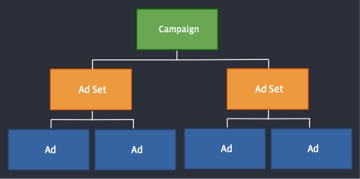

Ads belong to adsets which in turn fall in campaigns, keep that in mind when creating objects.

## Create

The create family functions are all very similar, they only consist of one argument; `body`. The `body` is a list that contains the settings of the object we create.

Some fields (setting specified in `body`) are required. These are listed in the documentation. However you may always *try* to create an object and debug using the errors returned.

### Campaign

```r
settings <- list(
  name = "My Campaign"
)

createCampaign(body = settings)
```

```
>  Error: The name has already been taken.
>  The pkg name field is required.
>  The objective field is required.
>  The budget type field is required.
```

Useful error messages, the name is already taken and we are missing some parameters, let’s fix that.

```r
settings <- list(
  name = "My Other Campaign",
  pkg_name = "something.com",
  objective = objective('installs'),
  budget_type = "daily",
  budget_daily = 1000,
  app_type = appType("game")
)

campaign <- createCampaign(body = settings)
```

### Adset

```r
adset <- createAdset(body = list(
   name = "My Adset",
   bid_type = bidType("cpi"),
   unit_price = 1000,
   budget_lifetime = 10000,
   campaign_id = campaign$id,
   audience_create_way = 2,
   app_show_type = appShowType("newsfeed"),
   audience_template_id = audience$id,
   click_url = "http://app.adjust.io"))
```

### Image

Now we can create an ad but this requires an image; let’s upload one. We’ll be promoting the oRion package so we’ll upload the R logo.

```r
image <- createImage(file = paste0(.libPaths(), "/png/img/Rlogo.png"))
```

### Ad

Now for the ad.

```r
body <- list(
   adset_id = adset$id,
   name = "testAd",
   icon_url = image$url,
   title = "Download oRion",
   desc = "Download oRion and interact with Orion from your R console",
   button_text = buttonText("install"))

ad <- createAd(body = body)
```

## Helpers

You might have noticed the use of odd-looking functions in the create-section above; i.e.: `buttonText`. These are helpers that attempts setting up objects slightly easier and more readable.

```r
settings  <- list(name = "Helpers",
                  budget_type = budgetType("daily"),
                  budget_daily = "1000",
                  pkg_name = "test.com",
                  objective = objective("installs"),
                  app_type = appType("game"),
                  web_type = webType("ecommerce"),
                  landing_page = landingPage("googlePlay"))

nohelpers  <- list(name = "Helpers",
                   budget_type = "daily",
                   budget_daily = "1000",
                   pkg_name = "test.com",
                   objective = "1",
                   app_type = "1",
                   web_type = "2",
                   landing_page = "1")

identical(settings, nohelpers)
```

```
>  [1] TRUE
```

```r
createCampaign(body = settings)
```

Run `?helpers` for more details.

## Update

The update family of functions are every bit the same as the create one; pass the `id` of the object you want to update along with the updated body.

```r
newSettings <- list(
  name = "Awesome campaign"
)

updateCampaign(campaign.id = campaign$id, body = newSettings)
```

## List

One can also retrieve the list of objects under his/her account with the list family of functions.

Valid objects:

- Campaigns
- Adsets
- Ads
- Audience targeting templates

```r
campaigns <- listCampaigns(n = 200)
adsets <- listAdsets(n = 100)
audiences <- listAudiences()
ads <- listAds(n = 300)
```

## Show

If you do not want to list all the objects you may retrieve one object in particular by calling its id.

```r
show_ad <- showAd(ad.id = sample(ads$id, 1))

show_adset <- showAdset(adset.id = sample(adsets$id, 1))
```

## Map

One can get lost or confused by the amount of information heshe is presented with, particularly when one is running numerous ads. The `map` function attempts to remedy to this problem

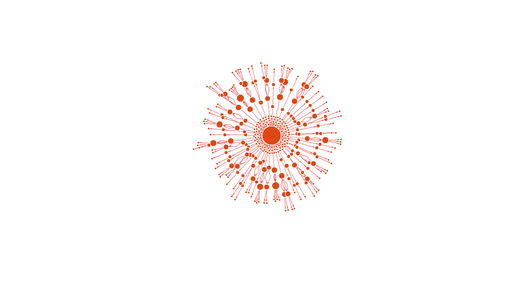

```r
map <- map(campaigns = campaigns, adsets = adsets, ads = ads, audiences = audiences)

g <- igraph::graph.data.frame(map[, 3:4], directed = TRUE)
plot(g, layout = igraph::layout.fruchterman.reingold(g),
     vertex.color = "#dd4814", vertex.label.family = "sans",
     vertex.label.color = hsv(h = 0 , s = 0, v = 0, alpha = 0),
     vertex.size = log1p(igraph::degree(g)) * 5, edge.arrow.size = 0.2,
     edge.arrow.width = 0.3, edge.width = 1,
     edge.color = hsv(h = 1, s = .59, v = .91, alpha = 0.7),
     vertex.frame.color="#FFFFFF")
```

## Get Data

Yo ucan use the `getReport` function to fetch data on the performance of your ads.

```r
# get daily adset ratios for the past 30 days by age and gender
dat <- getReport(column = c("ctr", "cpm", "cpc"),
                 group.by = c("datetime", "adset", "age", "gender"),
                 start = Sys.Date() - 30)

# get impressions and clicks for January 2016's ads
dat <- getReport(column = c("impression", "click"),
                 group.by = c("datetime", "ad"), start = "2016-01-01",
                 end = "2016-02-01")
```

## Delete

Then of course one can delete objects; let’s delete the objects we created here.

```r
deleteAd(ad.id = ad$id)
deleteAdset(adset.id = adset$id)
deleteAudience(audience.id = audience$id)
deleteCampaign(campaign.id = campaign$id)
```

Images cannot be deleted.